# FUZZY RULE-BASED SYSTEM. WANG & MENDEL ALGORITHM

Domingo José Caballero Navarro  
[Linkedin](https://www.linkedin.com/in/domingo-jos%C3%A9-caballero-navarro-56a29a24b/)

## Index

- 1. Introduction
- 2. Exploratory Data Analysis
- 1. Data Preprocessing
- 4. Data Fuzzification
  - 4.1 Fuzzy Variables
  - 4.2 Fuzzy Transformer
- 5. Inference
- 6. Wang y Mendel Rules Extraction
- 7. Results

# 1. Introduction

En esta práctica vamos a realizar la implementación del algoritmo Wang y Mendel para la extracción de reglas, a diferencia de la práctica anterior que realizabamos la extracción de las reglas del árbol de decisión. Mantendremos la mayor parte de la práctica anterior, es decir, las variables difusas y el transformador como también el motor de inferencia del sistema basado en reglas difusas.

# 2. Exploratory Data Analysis

En esta práctica vamos a realizar la implementación del algoritmo Wang y Mendel para la extracción de reglas, a diferencia de la práctica anterior que realizabamos la extracción de las reglas del árbol de decisión. Mantendremos la mayor parte de la práctica anterior, es decir, las variables difusas y el transformador como también el motor de inferencia del sistema basado en reglas difusas.

# 4. Fuzzificación de la base de datos

Como hemos comentado anteriormente mantendremos las partes de la práctica dos que nos sirvan, en este caso utilizaremos la clase de variables difusas y el transformador fuzzy.

### 4.1 Variables Difusas

Para simplificar la implementación de las variables difusas se utilizarán conjuntos difusos triangulares. A continuación, veremos qué atributos y qué funciones conforman esta clase.

Los atributos de la clase serán los siguientes:

- `universe`: El universo del discurso de la variable. Este universo será el array ordenado de todos los posibles valores que puede tomar la variable dada.
- `memb_func`: Un diccionario con los grados de pertenencia de cada elemento del universo del discurso para cada uno de los conjuntos difusos que se generen de la variable difusa. Dicho diccionario lo obtendremos de la función **_membership_functions**.
- `labels`: Etiquetas de cada uno de los conjuntos difusos, que estarán repartidas entre: **Low, Mid y High**.
- `name`: Nombre de la variable difusa.

Las funciones de la clase serán las siguientes:

- `_membership_functions`: Función interna para generar el diccionario con las distintas funciones de pertenencia.
- `fuzzify`: Función que devuelve el mejor conjunto difuso para un valor dentro del universo del discurso.
- `plot`: Función que muestra de manera gráfica los conjuntos difusos de la variable.

Posteriormente, explicaremos el código implementado en cada apartado para lograr un correcto funcionamiento. Pero antes de nada hay que tener en cuenta que para utilizar la clase, habrá que calcular previamente los triángulos de los conjuntos difusos. Para ello, se utilizará la estructura `fuzzy_points`, que es diccionario con la definición de los triángulos y forma `{label: [start, peak, end]}` para cada triángulo.

Una vez entendido el concepto y la estructura que conforman las variables difusas podemos comenzar a explicar la implementación del código. Dicha explicación la realizaremos conforme aparece el código en nuestra clase con comentarios.

```python
import numpy as np
import pandas as pd
import skfuzzy as fuzz
import matplotlib.pyplot as plt

class FuzzyVariable:
    def __init__(self, name, variable, fuzzy_points):

        # Para comenzar explicaremos como obtener el universo de nuestra variable: para obtener dicho universo
        # debemos ordenar aquellos valores únicos que puede tomar la variable, para ello hacemos uso de numpy.
        self.universe = np.array(np.sort(np.unique(variable)),dtype='float64')

        # Para obtener el diccionario con los grados de pertenencia realizaremos una llamada a la función _membship_functions.
        self.memb_func = self._membership_functions(self.universe, fuzzy_points)

        # Las etiquetas las obtenemos del diccionario que define los triángulos.
        self.labels = fuzzy_points.keys()
        self.name = name

    def _membership_functions(self, variable, fuzzy_points):
        # Este diccionario será en el que almacenemos los grados de pertenencia finales.
        fuzz_dict = {}

        # En este diccionario tendremos los correspondientes triángulos, para cada etiqueta tenemos
        # un triángulo con sus correspondientes puntos.
        pert = {}
        pert['Low'] = fuzz.trimf(self.universe,fuzzy_points['Low'])
        pert['Mid'] = fuzz.trimf(self.universe,fuzzy_points['Mid'])
        pert['High'] = fuzz.trimf(self.universe,fuzzy_points['High'])

        # A continuación, obtendremos el grado de pertenencia de cada valor en la variable con cada
        # uno de los posibles triángulos. Para ello tendremos un diccionario para cada etiqueta donde
        # guardaremos el grado de pertenencia de cada valor de la variable.
        dict_pert_low = {}
        dict_pert_mid = {}
        dict_pert_high = {}

        for x in variable:
            # Por lo tanto, para cada valor de la variable obtenemos el grado de pertenencia con los tres
            # posibles triángulos, es decir, para cada etiqueta.
            pert_low = fuzz.interp_membership(self.universe,pert['Low'],x)
            pert_mid = fuzz.interp_membership(self.universe,pert['Mid'],x)
            pert_high = fuzz.interp_membership(self.universe,pert['High'],x)

            dict_pert_low[x] = pert_low
            dict_pert_mid[x] = pert_mid
            dict_pert_high[x] = pert_high

        # El resultado final de recorrer todos los posibles valores será los grado de pertenencia en los
        # posibles triángulos.
        fuzz_dict['Low'] = dict_pert_low
        fuzz_dict['Mid'] = dict_pert_mid
        fuzz_dict['High'] = dict_pert_high

        # Devolvemos el diccionario con los grados de pertenencia.
        return fuzz_dict

    def fuzzify(self, value):
        best = ''
        max_val = -1
        # Recorremos todas las posibles etiquetas para obtener la mejor.
        for label in self.labels:
            # Obtenemos el grado de pertenencia del valor para cada posible etiqueta y la comparamos con la
            # mejor hasta el momento. Por lo tanto, al final de recorrer todas las etiquetes obtendremos
            # aquella etiqueta donde el valor pasado tiene el mayor grado de pertenencia.
            aux_val = self.memb_func[label][value]
            if aux_val > max_val:
                max_val = aux_val
                best = label
        return best

    def plot(self):
        fig, ax0 = plt.subplots(nrows=1)
        for label in self.labels:
            ax0.plot(self.universe, self.fuzz_dict[label], linewidth=1.5, label=label)
        ax0.set_title(self.name)
        ax0.legend()
        plt.tight_layout()
```

### 4.2 Transformador Fuzzy

Deberemos implementar un transformador para llevar a cabo la fuzzificación de la base de datos, dicho transformador se encargará de generar las variables difusas a partir de las variables continuas. La implementación consiste en generar las variables difusas necesarias y utilizar la función `fuzzify` para fuzzificar los valores.

Para ello comenzaremos explicando cómo funciona el transformador, cuáles son sus atributos y cuáles son sus funciones. Los atributos de la clase son los siguientes:

- `sets`: Número de conjuntos difusos para cada variable, por defecto son 3.
- `labels`: Etiquetas difusas para los conjuntos, por defecto son Low, Mid y High.

La clase se dividirá en las funciones:

- `fit`: encargado de aprender las variables difusas a partir de los datos.
- `transform`: creará una nueva base de datos sustituyendo los valores continuos por las etiquetas de las variables.
- `fit_transform`: auxiliar para hacer los dos procedimientos en un solo paso.
- `_equal_width`: Esta función coge una variable en formato `NumPy` y genera cortes de igual anchura. Es decir, si la variable es `[1,2,3,4,5,6,7]` y tiene que hacer 3 cortes, devuelve los puntos `[1,4,7]`.
- `_expand_points`: Esta función coge los puntos de `equal_width` y los expande para generar los triángulos en el formato `[start, peak, end]`.

A continuación, explicaremos el código implementado conforme aparece en la práctica.

```python
from sklearn.base import BaseEstimator

# Ejemplo de la estructura básica de un algoritmo que hereda de BaseEstimator siguiendo la estructura de SciKit
class FuzzyEncoder(BaseEstimator):
    # constructor
    def __init__(self, sets=3, labels=['Low', 'Mid', 'High']):
        self.fuzzy_vars = {}
        self.sets = sets
        self.labels = labels

    # siguiendo las guias de scikit-learn, creamos las funciones fit para el entrenamiento
    def fit(self, X):

        # Para aprender las variables difusas a partir de los datos tenemos que realizar el entrenamiento para
        # así poder realizar una transformación con lo aprendido. Dicho entrenamiento consistirá en generar todas
        # aquellas variables difusas posibles a partir de las variables continuas de una base de datos de entrenamiento.

        for n in range(len(X[0,:])):
            # Comprobamos que la variable seleccionada sea continua y calculamos los fuzzy points de dicha variable
            # para posteriormente crear la variable difusa. Realizando así el entrenamiento con cada variable continua.
            if type(X[0,n]) == float :
                fuzzy_points = self._expand_points(self._equal_width(X[:,n],self.sets),self.labels)
                self.fuzzy_vars[features[n]] = FuzzyVariable(features[n],X[:,n],fuzzy_points)
        return self

    # y transform para aplicar lo aprendido y transformar la base de datos creando una nueva
    def transform(self, X):
        new_X = X.copy()

        # A continuación, tenemos que aplicar lo aprendido anteriormente por lo tanto tenemos que recorrer otra vez la base
        # de datos obteniendo la fuzzificación para cada valor de cada variable.
        for n in range(len(new_X[0,:])):

            # Comprobamos que la variable haya sido entrenada previamente y realizamos la transformación. Para ello almacenamos
            # los índices de la variable y calculamos la fuzzificación para cada valor con fuzzify. Por último, utilizando la
            # función put que nos proporciona numpy modificamos los valores continuos por los difusos.

            if features[n] in self.fuzzy_vars:
                indices = np.arange(0,len(new_X[:,n]),1)
                fuzzificadas = [self.fuzzy_vars[features[n]].fuzzify(x) for x in new_X[:,n]]
                new_X[:,n].put(indices,fuzzificadas)

        return new_X

    def fit_transform(self, X):
        return self.fit(X).transform(X)

    def _equal_width(self, var, sets):
        try:
            cut = pd.cut(var, sets - 1)
            sol = [cat.left for cat in cut.categories] + [cut.categories[-1].right]
        except ValueError:
            cut = pd.cut(var, sets - 1, duplicates='drop')
            sol = [var.min()] + [cat.left for cat in cut.categories] + [cut.categories[-1].right]
        sol[0] = var.min()
        return sol

    def _expand_points(self, fp, labels):
        ep = {}
        expanded_points = [fp[0]] + fp + [fp[-1]]

        for i in range(len(expanded_points) - 2):
            ep[labels[i]] = [expanded_points[i], expanded_points[i+1], expanded_points[i+2]]

        return ep
```

Para poder realizar la transformación primero de todo tenemos que realizar un prepocesacimiento de la base de datos. Partimos de la base de datos obtenida en la práctica uno donde tenemos que modificar lo siguiente:

- La variable `Location` hay que eliminarla. Esto lo vamos a hacer para que el árbol que salga no ramifique demasiado
- Las variables de puntos cardinales hay que simplificarlas. Se han de quedar simplemente con los cuatro puntos cardinales principales (N, S, E, W)

```python
# Preprocesamiento de la base de datos de la práctica uno.
import pandas as pd
weather = pd.read_csv('weatherAUS_withoutNaN.csv')

# Eliminamos la variable Location.
del(weather['Location'])

# Para simplificar las variables con puntos cardinales haremos uso de replace para quedarnos
# con los cuatro puntos cardinales principales.
weather['WindGustDir'].replace('WNW','W', inplace=True)
weather['WindGustDir'].replace('WSW','W', inplace=True)
weather['WindDir9am'].replace('WNW','W', inplace=True)
weather['WindDir9am'].replace('WSW','W', inplace=True)
weather['WindDir3pm'].replace('WNW','W', inplace=True)
weather['WindDir3pm'].replace('WSW','W', inplace=True)

weather['WindGustDir'].replace('NE','N', inplace=True)
weather['WindGustDir'].replace('NNW','N', inplace=True)
weather['WindGustDir'].replace('NNE','N', inplace=True)
weather['WindGustDir'].replace('NW','N', inplace=True)
weather['WindDir9am'].replace('NE','N', inplace=True)
weather['WindDir9am'].replace('NNW','N', inplace=True)
weather['WindDir9am'].replace('NNE','N', inplace=True)
weather['WindDir9am'].replace('NW','N', inplace=True)
weather['WindDir3pm'].replace('NE','N', inplace=True)
weather['WindDir3pm'].replace('NNW','N', inplace=True)
weather['WindDir3pm'].replace('NNE','N', inplace=True)
weather['WindDir3pm'].replace('NW','N', inplace=True)

weather['WindGustDir'].replace('SSE','S', inplace=True)
weather['WindGustDir'].replace('SE','S', inplace=True)
weather['WindGustDir'].replace('SSW','S', inplace=True)
weather['WindGustDir'].replace('SW','S', inplace=True)
weather['WindDir9am'].replace('SSE','S', inplace=True)
weather['WindDir9am'].replace('SE','S', inplace=True)
weather['WindDir9am'].replace('SSW','S', inplace=True)
weather['WindDir9am'].replace('SW','S', inplace=True)
weather['WindDir3pm'].replace('SSE','S', inplace=True)
weather['WindDir3pm'].replace('SE','S', inplace=True)
weather['WindDir3pm'].replace('SSW','S', inplace=True)
weather['WindDir3pm'].replace('SW','S', inplace=True)


weather['WindGustDir'].replace('ENE','E', inplace=True)
weather['WindGustDir'].replace('ESE','E', inplace=True)
weather['WindDir9am'].replace('ENE','E', inplace=True)
weather['WindDir9am'].replace('ESE','E', inplace=True)
weather['WindDir3pm'].replace('ENE','E', inplace=True)
weather['WindDir3pm'].replace('ESE','E', inplace=True)

weather['RainToday'].replace(0,'No', inplace=True)
weather['RainToday'].replace(1,'Yes', inplace=True)

weather
```

|  | MinTemp | MaxTemp | Rainfall | Evaporation | Sunshine | WindGustDir | WindGustSpeed | WindDir9am | WindDir3pm | WindSpeed9am | WindSpeed3pm | Humidity9am | Humidity3pm | Pressure9am | Cloud9am | Cloud3pm | Temp9am | RainToday | RainTomorrow |
| --- | --- | --- | --- | --- | --- | --- | --- | --- | --- | --- | --- | --- | --- | --- | --- | --- | --- | --- | --- |
| 0 | 13.4 | 22.900000 | 0.6 | 5.468232 | 7.611178 | W | 44.000000 | W | W | 20.0 | 24.0 | 71.0 | 22.0 | 1007.7 | 8.000000 | 5.406447 | 16.9 | No | No |
| 1 | 7.4 | 25.100000 | 0.0 | 5.468232 | 7.611178 | W | 44.000000 | N | W | 4.0 | 22.0 | 44.0 | 25.0 | 1010.6 | 6.391001 | 5.406447 | 17.2 | No | No |
| 2 | 12.9 | 25.700000 | 0.0 | 5.468232 | 7.611178 | W | 46.000000 | W | W | 19.0 | 26.0 | 38.0 | 30.0 | 1007.6 | 6.391001 | 2.000000 | 21.0 | No | No |
| 3 | 9.2 | 28.000000 | 0.0 | 5.468232 | 7.611178 | N | 24.000000 | S | E | 11.0 | 9.0 | 45.0 | 16.0 | 1017.6 | 6.391001 | 5.406447 | 18.1 | No | No |
| 4 | 17.5 | 32.300000 | 1.0 | 5.468232 | 7.611178 | W | 41.000000 | E | N | 7.0 | 20.0 | 82.0 | 33.0 | 1010.8 | 7.000000 | 8.000000 | 17.8 | No | No |
| ... | ... | ... | ... | ... | ... | ... | ... | ... | ... | ... | ... | ... | ... | ... | ... | ... | ... | ... | ... |
| 145455 | 2.8 | 23.400000 | 0.0 | 5.444427 | 7.635899 | E | 31.000000 | S | E | 13.0 | 11.0 | 51.0 | 24.0 | 1024.6 | 5.543103 | 4.834532 | 10.1 | No | No |
| 145456 | 3.6 | 25.300000 | 0.0 | 5.444427 | 7.635899 | N | 22.000000 | S | N | 13.0 | 9.0 | 56.0 | 21.0 | 1023.5 | 5.543103 | 4.834532 | 10.9 | No | No |
| 145457 | 5.4 | 26.900000 | 0.0 | 5.444427 | 7.635899 | N | 37.000000 | S | W | 9.0 | 9.0 | 53.0 | 24.0 | 1021.0 | 5.543103 | 4.834532 | 12.5 | No | No |
| 145458 | 7.8 | 27.000000 | 0.0 | 5.444427 | 7.635899 | S | 28.000000 | S | N | 13.0 | 7.0 | 51.0 | 24.0 | 1019.4 | 3.000000 | 2.000000 | 15.1 | No | No |
| 145459 | 14.9 | 30.383195 | 0.0 | 5.444427 | 7.635899 | E | 41.268373 | E | E | 17.0 | 17.0 | 62.0 | 36.0 | 1020.2 | 8.000000 | 8.000000 | 15.0 | No | No |

145460 rows × 19 columns

```python
features = weather.columns
attributes = features[:-1]
target = features[-1]
features
```

```
Index(['MinTemp', 'MaxTemp', 'Rainfall', 'Evaporation', 'Sunshine',
       'WindGustDir', 'WindGustSpeed', 'WindDir9am', 'WindDir3pm',
       'WindSpeed9am', 'WindSpeed3pm', 'Humidity9am', 'Humidity3pm',
       'Pressure9am', 'Cloud9am', 'Cloud3pm', 'Temp9am', 'RainToday',
       'RainTomorrow'],
      dtype='object')
```

```python
X = weather[attributes]
X = X.to_numpy()
```

```python
y = weather[target]
y = y.to_numpy().reshape(len(y),1)
y[y == 'No'] = 0
y[y == 'Yes'] = 1
```

```python
fuzzy_vars = FuzzyEncoder()
fuzzy_vars.fit(X)
```

```
FuzzyEncoder()
```

Para crear el sistema basado en reglas difusas necesitamos utilizar `scikit-fuzzy` y el sistema de control. Eso significa que se necesita un procesado previo para las variables discretas.

Se necesitan dos elementos para crear un sistema basado en reglas con `scikit-fuzzy`:

- Universo del discurso. Para una variable discreta, será una enumeración de sus valores. Esto quiere decir que una variable `['N', 'S', 'E', 'W']` tendrá como universo del discurso `[0,1,2,3]`
- Una función de grados de pertenencia. En lugar de utilizar `fuzz.trapmf` o `fuzz.trimf`, la función será `1` cuando coincida con el elemento y `0` cuando no coincida.

Para ello tenemos que establecer cuáles son las variables discretas y empezar la discretización.

```python
discrete = ['WindGustDir','WindDir9am','WindDir3pm']
```

```python
def get_discrete(X, var):
    return {
        'universe': np.array([0,1,2,3]),
        'pert': {
            'N': np.array([1,0,0,0]),
            'S': np.array([0,1,0,0]),
            'E': np.array([0,0,1,0]),
            'W': np.array([0,0,0,1])
        }
    }
```

Con este generador, dada la función `get_discrete` que nos genera las variables discretas, se consigue un diccionario por cada una de las variables discretas

```python
discrete_variables = {att: get_discrete(X, att) for att in discrete}
discrete_variables['RainToday'] = { 'universe': [0,1],
                                   'pert':{'No': [1,0],
                                           'Yes': [0,1]}}
discrete_variables
```

```
{'WindGustDir': {'universe': array([0, 1, 2, 3]),
  'pert': {'N': array([1, 0, 0, 0]),
   'S': array([0, 1, 0, 0]),
   'E': array([0, 0, 1, 0]),
   'W': array([0, 0, 0, 1])}},
 'WindDir9am': {'universe': array([0, 1, 2, 3]),
  'pert': {'N': array([1, 0, 0, 0]),
   'S': array([0, 1, 0, 0]),
   'E': array([0, 0, 1, 0]),
   'W': array([0, 0, 0, 1])}},
 'WindDir3pm': {'universe': array([0, 1, 2, 3]),
  'pert': {'N': array([1, 0, 0, 0]),
   'S': array([0, 1, 0, 0]),
   'E': array([0, 0, 1, 0]),
   'W': array([0, 0, 0, 1])}},
 'RainToday': {'universe': [0, 1], 'pert': {'No': [1, 0], 'Yes': [0, 1]}}}
```

```python
target_variable = {'name': target,
                   'universe': [0,1],
                   'pert': {0: [1,0],
                            1: [0,1]}}
target_variable
```

```
{'name': 'RainTomorrow', 'universe': [0, 1], 'pert': {0: [1, 0], 1: [0, 1]}}
```

# 5. Motor de inferencia

Finalmente creamos el sistema basado en reglas difusas. Vamos a tener una clase abstracta general y una clase que extienda de esta y genera las reglas con el algoritmo Wang y Mendel.

La clase abstracta `RuleBasedSystem` se dividirá en las funciones:

- `fit`: Metodo abstracto que se programará en la clase que extienda de `RuleBasedSystem`.
- `_create_rbs`: encargado de aprender el sistema basado en reglas. Tiene los siguientes parámetros:
  - `rule_list`: Lista de reglas con las que se creará el sistema de control
  - `fuzzy_variables`: Variables difusas extraidas de `FuzzyEncoder.fuzzy_vars`.
  - `discrete_variables`: Diccionario con las variables discretas.
  - `target_variable`: Diccionario con la variable objetivo.
- `predict`: Devuelve la clasificación para una instancia de la base de datos segun el sistema basado en reglas.
- `score`: Devuelve el score de la base de datos.

A continuación, explicaremos con comentarios como hemos realizado la implementación de la clase:

```python
from skfuzzy import control as ctrl
from abc import ABC, abstractmethod

class RuleBasedSystem(ABC):
    def __init__(self):
        self.ctrl = None

    def _create_rbs(self, rule_list, fuzzy_variables, discrete_variables, target_variable):
        # TODO: PASO 1

        # Hay que obtener todos los antecedentes. Un antecedente en
        # scikit-fuzzy se crea con ante = ctrl.Antecedent(universe, variable_name)
        # Para ello, tanto en fuzzy_variables como en discrete_variables
        # deberia estar ya representado el universo de cada variable

        # Ademas, para cada antecedente hay que crear todos los conjuntos difusos
        # (o valores para las variables discretas) correspondientes. Tenemos las etiquetas
        # en las fuzzy_variables, y se pueden obtener tambien de las variables discretas
        # Para cada conjunto difuso se crea con ante[label] = pert, donde ya tenemos
        # las funciones de pertenencia tanto en fuzzy_variables como en discrete_variables

        # ----------------------------------------------------------------------------------

        # Para crear los antecedentes tenemos que recorrer tanto las variables difusas como las discretas.
        # Cada antecedente lo guardaremos en el diccionario antecedents_var para tenerlos más accesibles.

        # Comenzamos recorriendo las variables difusas.

        antecedents_var = {}
        for fuzzy_var in fuzzy_variables:

            # Creamos el antecedente para cada variable con su universo y guardamos el antecedente.
            locals()[fuzzy_var] = ctrl.Antecedent(fuzzy_variables[fuzzy_var].universe, fuzzy_var)

            # Para cada etiqueta de la variable añadimos el grado de pertenencia en el antecedente.
            for label in fuzzy_variables[fuzzy_var].labels:
                locals()[fuzzy_var][label] = np.array(list(fuzzy_variables[fuzzy_var].memb_func[label].values()))

            # Guardamos el antecedente en el diccionario.
            antecedents_var[fuzzy_var] = locals()[fuzzy_var]

        # Seguimos con las variables discretas.
        for discrete_var in discrete_variables:

            # Creamos el antecedente para cada variable con su universo al igual que con las variables difusas.
            antecedent = ctrl.Antecedent(discrete_variables[discrete_var]['universe'], discrete_var)

            # Y para cada etiqueta añadimos el grado de pertenencia en el antecedente.
            for label in discrete_variables[discrete_var]['pert']:
                antecedent[label] = discrete_variables[discrete_var]['pert'][label]

            # Guardamos el antecedente en el diccionario.
            antecedents_var[discrete_var] = antecedent
        # TODO: PASO 2

        # Para crear el consecuente se hace con conseq = ctrl.Consequent(universe, conseq_name)
        # Por eso es mejor pasarlo por separado. De igual manera, hay que asignar cada uno
        # de los valores que puede tomar y sus funciones de pertenencia.

        # ----------------------------------------------------------------------------------

        # Creamos el consecuente con el diccionario target_variable.
        consequent = ctrl.Consequent(target_variable['universe'],target_variable['name'])

        # Añadimos el grado de pertenencia de cada etiqueta.
        for label in target_variable['pert']:
                consequent[label] = target_variable['pert'][label]


        rules = []
        # TODO: PASO 3

        # Finalmente hay que generar las reglas. Para ello se crean con
        # rule = ctrl.Rule(antecedent=antecedents, consequent=consequent)
        # Aqui trabajamos con los antecedentes y el consecuente que hemos generado
        # anteriormente. Con la lista de reglas que tenemos del arbol, generamos
        # las reglas con el formato de scikit-fuzzy. antecedents es una union logica
        # de terminos, esto quiere decir, ante1[label1] & ante2[label2]...
        # De igual manera, el consecuente es conseq[label] para el valor correspondiente
        # de la regla. Habra que haber almacenado los antecedentes para poder acceder
        # a ellos en funcion del nombre de la columna que aparece en la regla.

        # ----------------------------------------------------------------------------------

        # Por último, tenemos que generar todas las reglas y para ello recorremos la lista de reglas
        # obtenidas del árbol.
        contador = 0
        for rule in rule_list:
            contador += 1
            # Añadimos los antecedentes de la regla almacenados en rule[0].
            for ante in range(len(rule[0])):
                if ante == 0:
                    antecedents = antecedents_var[rule[0][ante][0]][rule[0][ante][1]]

                # Y concatenamos todos los antecedentes de la regla.
                else:
                    antecedents = antecedents & antecedents_var[rule[0][ante][0]][rule[0][ante][1]]

            # Finalmente añadimos el consecuente almacenado en rule[1] y añadimos la regla.
            rule_ = ctrl.Rule(antecedent=(antecedents), consequent=consequent[rule[1]])
            rules.append(rule_)

        # Por último, añadimos todas las reglas al sistema de control.
        self.ctrl = ctrl.ControlSystem(rules=rules)

    @abstractmethod
    def fit():
        pass

    def predict(self, x):
        sim = ctrl.ControlSystemSimulation(self.ctrl, flush_after_run=1000)
        # Para predecir, hay que añadir los valores de la instancia al sistema
        # de simulacion de control. Primero hay que ver si existe el antecedente
        # en el sistema de control (posiblemente las reglas extraidas del arbol
        # no tengan todas las caracteristicas de la instancia). En caso afirmativo,
        # la variable 'temperatura' = 8.7 se añade como sim.input['temperatura'] = 8.7

        # ----------------------------------------------------------------------------------

        # Recorremos todas las variables comprobando si existe el antecedente o no, en caso afirmativo,
        # añadimos el valor correspondiente x[n].
        for n in range(len(x)):
            try:
                sim.input[attributes[n]] = x[n]
            except:
                continue

        # Despues se calculan los grados de las reglas
        sim.compute()

        # Finalmente se devuelve el resultado que se encuentra en sim.output['target']
        # si la variable a predecir se llama 'target'.
        return sim.output[target]

    def score(self, X, y):
        all_predictions = np.array([[round(self.predict(x))] for x in X])
        return np.sum(all_predictions==y)/y.shape[0]
```

# 6. Extracción de reglas Wang y Mendel

La clase `WangMendelRuleBasedSystem` se encargará de obtener las reglas mediante el algoritmo de Wang y Mendel. En esta clase podemos encontrar las siguientes funciones:

- `_extract_rules`: encargado de procesar la base de datos y obtener las reglas. Para esta función hemos añadido un parámetro, se trata de **selected_variables**, para el filtrado de variables dado que si no realizamos un filtrado obtendriamos una gran cantidad de reglas que el sistema no soporta.
- `fit`: Método que entrena el sistema basado en reglas.

```python
class WangMendelRuleBasedSystem(RuleBasedSystem):
    def __init__(self):
        super().__init__()

    # Se recomienda este formato para extraer las reglas
    # del arbol, ya que simplifica la manera de tratar los
    # antecedentes y consecuentes a la hora de generar el
    # sistema basado en reglas

    def _extract_rules(self, X, y, fuzzy_variables, selected_variables):

        # Tenemos un diccionario donde almacenamos el grado de recubrimiento para cada regla.
        dict_rules = {}

        # Recorremos todas las filas de la base de datos.
        for n in range(len(X)):
            degree = 1
            antecedents = []

            # Para cada fila creamos la regla correspondiente.
            for j in range(len(attributes)):

                # Comprobamos que la variable esta entre las seleccionadas para
                # realizar el filtrado.
                if attributes[j] in selected_variables:

                    # Y comprobamos si se trata de una variable difusa o discreta. En el
                    # caso de ser difusa tendremos que actualizar el grado de pertenencia.
                    # Para discretas no haría falta ya que siempre sería 1.
                    if attributes[j] in fuzzy_variables:
                        fuzzy_val = fuzzy_vars.fuzzy_vars[attributes[j]].fuzzify(X[n,j])
                        degree *= fuzzy_vars.fuzzy_vars[attributes[j]].memb_func[fuzzy_val][X[n,j]]

                        ante = (attributes[j], fuzzy_val)

                    else:
                        ante = (attributes[j], X[n,j])

                    # Guardamos el antecedente junto con el resto.
                    antecedents.append(ante)

            # Creamos la regla de la forma: ((antecedent),consequent) para poder manejar
            # mejor que reglas están o no en el diccionario.

            rule = (tuple(antecedents), y[n][0])

            # Comprobamos si los antecedentes de la regla están en el diccionario. Si no
            # están se añade directamente la regla al diccionario. En caso contrario de que
            # sí esten, tendremos que calcular cuál es la regla con mayor grado de recubrimiento,
            # ya que esa debe permanecer.

            if ((rule[0], 0) in dict_rules) or ((rule[0], 1) in dict_rules):
                try:
                    if degree > dict_rules[(rule[0], 1)]:
                        del(dict_rules[(rule[0], 1)])
                        dict_rules[rule] = degree
                except:
                    try:
                        if degree > dict_rules[(rule[0], 0)]:
                            del(dict_rules[(rule[0], 0)])
                            dict_rules[rule] = degree
                    except:
                        continue

            else:
                dict_rules[rule] = degree


        # Obtenemos todas las reglas del diccionario con .keys()
        dict_keys = dict_rules.keys()

        # Y modificamos el formato de las reglas: ([antecedents],consequent) para que
        # nuestro sistema basado en reglas funcione correctamente.
        all_rules = []
        for x in dict_keys:
            rule_ = (list(x[0]),x[1])
            all_rules.append(rule_)

        # Para el algoritmo de Wang y Mendel, que se debe realizar en esta funcion
        # Ss recomienda el uso de un diccionario del tipo {rule: membership}
        # para que a la hora de almacenar las reglas y comprobar si hay que actualizar
        # el grado de pertenencia, sea lo mas eficiente posible.
        # Recordad que para que sea compatible con el algoritmo de la practica anterior,
        # habra que transformar ese diccionario a una lista antes de devolverlo.

        # fuzzy_variables sera un subconjunto de las variables difusas del problema,
        # ya que un problema con tantas instancias y variables puede resultar muy
        # complejo de extraer todas las reglas

        return all_rules


    def fit(self, X, y, fuzzy_variables, discrete_variables, target_variable, selected_variables):
        rule_list = self._extract_rules(X, y, fuzzy_variables, selected_variables)
        self._create_rbs(rule_list, fuzzy_variables, discrete_variables, target_variable)
```

```python
copy_X = X.copy()
copy_X[copy_X == 'No'] = 0
copy_X[copy_X == 'Yes'] = 1
copy_X[copy_X == 'N'] = 0
copy_X[copy_X == 'S'] = 1
copy_X[copy_X == 'E'] = 2
copy_X[copy_X == 'W'] = 3
copy_X
```

```
array([[13.4, 22.9, 0.6, ..., 5.406447091800981, 16.9, 0],
       [7.4, 25.1, 0.0, ..., 5.406447091800981, 17.2, 0],
       [12.9, 25.7, 0.0, ..., 2.0, 21.0, 0],
       ...,
       [5.4, 26.9, 0.0, ..., 4.83453237410072, 12.5, 0],
       [7.8, 27.0, 0.0, ..., 2.0, 15.1, 0],
       [14.9, 30.38319541693189, 0.0, ..., 8.0, 15.0, 0]], dtype=object)
```

Para realizar una comprobación inicial, estudiaremos el funcionamiento usando los atributos Humidity3pm, WindDir3pm y RainToday

```python
selected_variables = ['Humidity3pm', 'WindDir3pm', 'RainToday']
selected_variables
```

```
['Humidity3pm', 'WindDir3pm', 'RainToday']
```

Los resultados son:

```python
from time import time
WM_rules = WangMendelRuleBasedSystem()
t = time()
WM_rules.fit(X,y,fuzzy_vars.fuzzy_vars,discrete_variables,target_variable,selected_variables)
t = time() - t
print("Training time: ",t)
```

```
Training time:  2.742729425430298
```

Se produce un score y una relacion score/tiempo tal que:

```python
ts = time()
score = WM_rules.score(copy_X,y)
ts = time() - ts
print("Score: ",score)
print("Score time: ",ts)
```

```
Score:  0.6084834318713048
Score time:  194.6715407371521
```

```python
selected_variables2 = ['Humidity3pm', 'WindDir3pm', 'WindGustSpeed', 'RainToday']
selected_variables2
```

```
['Humidity3pm', 'WindDir3pm', 'WindGustSpeed', 'RainToday']
```

```python
from time import time
WM_rules2 = WangMendelRuleBasedSystem()
t2 = time()
WM_rules2.fit(X,y,fuzzy_vars.fuzzy_vars,discrete_variables,target_variable,selected_variables2)
t2 = time() - t2
print("Training time: ",t2)
```

```
Training time:  3.9997384548187256
```

```python
ts2 = time()
score2 = WM_rules2.score(copy_X,y)
ts2 = time() - ts2
print("Score: ",score2)
print("Score time: ",ts2)
```

```
Score:  0.7850061872679774
Score time:  458.56861996650696
```

# 7. Resultados

Para finalizar esta práctica, el alumno deberá ejecutar el algoritmo con distintos conjuntos de variables difusas, y compararlo tanto en score como en tiempo de ejecución con el algoritmo de la práctica anterior. Habrá que hacer comparativas mínimo con conjuntos de 3, 4 y 5 variables difusas.

Podemos dividir el estudio de este algortimo en dos partes, una primera donde tratamos la influencia de la variable selected_variables en el funcionamiento de este, y otra donde comparamos su funcionamiento con el sistema de reglas de la práctica anterior

### Influencia de selected_variables

Para el estudio de la influencia de selected variables procederemos estudiando el comportamiento del algoritmo al añadir más variables al atributo selected_variables, aumentando el tamaño de las reglas a generar. Es por ello que pasamos a estudiar el comportamiento en 3 casos distintos, con 2, 3 y 4 variables. Por ello realizamos los siguientes estudios:

Para ello tomamos inicialmente Humidity3pm y RainToday por un lado, que fueron algunas de las variables por las que se ramificaba pen mayor medida el arbol fuzzificado enla práctica anterior

```python
from time import time

selected_variables = ['Humidity3pm', 'RainToday']

WM_rules = WangMendelRuleBasedSystem()
t1 = time()
WM_rules.fit(X,y,fuzzy_vars.fuzzy_vars,discrete_variables,target_variable,selected_variables)
t1 = time() - t1
print("Training time: ",t1)

ts1 = time()
score1 = WM_rules.score(copy_X,y)
ts1 = time() - ts1
print("Score: ",score1)
print("Score time: ",ts1)
```

```
Training time:  2.260378837585449
Score:  0.37898391310325863
Score time:  80.0306191444397
```

Un estudio añadiendo Cloud3pm a Humidity3pm y RainToday, que obtiene los sigueintes resultados:

```python
selected_variables = ['Humidity3pm', 'RainToday','Cloud3pm']

WM_rules = WangMendelRuleBasedSystem()
t1_2 = time()
WM_rules.fit(X,y,fuzzy_vars.fuzzy_vars,discrete_variables,target_variable,selected_variables)
t1_2 = time() - t1_2
print("Training time: ",t1_2)

ts1_2 = time()
score1_2 = WM_rules.score(copy_X,y)
ts1_2 = time() - ts1_2
print("Score: ",score1_2)
print("Score time: ",ts1_2)
```

[output not shown]

Otro estudio añadiendo la variable Pressure9am a esta lista, dando lugar a un total de 4 variables en selected_variables, donde los resultados obtenidos son los siguientes:

```python
selected_variables = ['Humidity3pm', 'RainToday','Cloud3pm','Pressure9am']

WM_rules = WangMendelRuleBasedSystem()
t1_3 = time()
WM_rules.fit(X,y,fuzzy_vars.fuzzy_vars,discrete_variables,target_variable,selected_variables)
t1_3 = time() - t1_3
print("Training time: ",t1_3)

ts1_3 = time()
score1_3 = WM_rules.score(copy_X,y)
ts1_3 = time() - ts1_3
print("Score: ",score1_3)
print("Score time: ",ts1_3)
```

```
Training time:  4.0246851444244385
Score:  0.7870686099271277
Score time:  378.0745539665222
```

Mediante una gráfica podemos estudiar la evolución de score al ir añadiendo variables, de tal froma que podemos observar que, a mayor número de variables empleadas, mayor probabilidad de acierto. De nuevo, al influir la variable seleccionada, cabe destacar que el hecho de ir añadiendo una u otra variable tiene repercusión directa en la precisión lograda.

```
No artists with labels found to put in legend.  Note that artists whose label start with an underscore are ignored when legend() is called with no argument.
```

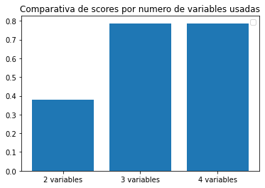

```python
names = ['2 variables', '3 variables', '4 variables']
Y_plt = [score1,score1_2,score1_3]
#plt.ylim([0.7,0.85])
plt.bar(names,Y_plt)
plt.title('Comparativa de scores por numero de variables usadas')
plt.legend()
plt.show()
```

En lo relativo a los tiempos de obtencion del sistema de reglas y ejecucion del score, al igual que el score, como era de esperar, aumentan a mayor cantidad de variables que usemos para formar las reglas, algo que podemos observar en la sigueinte gráfica:

```
No artists with labels found to put in legend.  Note that artists whose label start with an underscore are ignored when legend() is called with no argument.
```

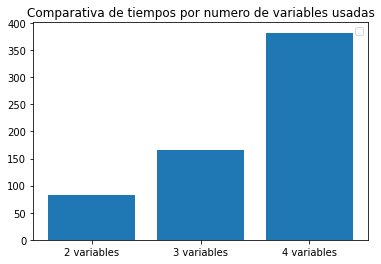

```python
names = ['2 variables', '3 variables', '4 variables']
Y_plt = [(ts1+t1),(ts1_2+t1_2),(ts1_3+t1_3)]
#plt.ylim([0.7,0.85])
plt.bar(names,Y_plt)
plt.title('Comparativa de tiempos por numero de variables usadas')
plt.legend()
plt.show()
```

```
No artists with labels found to put in legend.  Note that artists whose label start with an underscore are ignored when legend() is called with no argument.
```

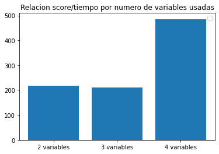

```python
names = ['2 variables', '3 variables', '4 variables']
Y_plt = [((ts1+t1)/score1),((ts1_2+t1_2)/score1_2),((ts1_3+t1_3)/score1_3)]
#plt.ylim([0.7,0.85])
plt.bar(names,Y_plt)
plt.title('Relacion score/tiempo por numero de variables usadas')
plt.legend()
plt.show()
```

### Comparativa con sistema basado en reglas

Por último, pasamos a estudiar su comportamiento frente al sistema basado en reglas de la práctica anterior, donde, para mayor limpieza del código en la celda siguiente colocaremos los resultados ya obtenidos en la anterior práctica, tomando para ello tres casos distintos, obtenidos variando la profundidad del árbol discreto para tres casos distintos, con altura máxima de 2, 3 y 4.

```python
# Para altura 2 los resultados obtenidos son:
## El arbol a partir del cual se obtienen las reglas es tal que:
# Feature Humidity3pm
#	High: Feature RainToday
#		No: Class value: Yes	Counts: (4904, 8747)
#		Yes: Class value: Yes	Counts: (7275, 9397)
#	Low: Feature WindDir3pm
#		E: Class value: No	Counts: (2927, 2982)
#		N: Class value: No	Counts: (5070, 5494)
#		S: Class value: No	Counts: (4602, 4662)
#		W: Class value: No	Counts: (3812, 3968)
#	Mid: Feature RainToday
#		No: Class value: No	Counts: (76375, 88080)
#		Yes: Class value: No	Counts: (14832, 22130)

#Los resultados de score y tiempo son los sigueintes para prof 2:


tiempo_r_2= 113.07 +  3.8
score_r_2= 0.82

#Para profundidad 3 son de :
tiempo_r_3= 4.799 + 300.16
score_r_3=  0.8262

#Para profundidad 4 son de :
tiempo_r_4=  6.095 + 726.01
score_r_4= 0.827
```

Destacamos que las reglas generadas por las ramificaciones del arbol anterior son distintas a lsa variables que elegimos en selected_variables, lo que implica que las reglas son distintas a las de Wang y Mendel.El score obtenido comparando con nuestro sistema de reglas por Wang y Mendel de dos variables, lo podemos comparar mediante la siguiente grafica es :

```
No artists with labels found to put in legend.  Note that artists whose label start with an underscore are ignored when legend() is called with no argument.
```

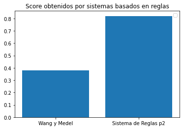

```python
names = [ 'Wang y Mendel', 'Sistema de Reglas p2']
Y_plt = [score1,score_r_2]
#plt.ylim([0.7,0.85])
plt.bar(names,Y_plt)
plt.title('Score obtenidos por sistemas basados en reglas')
plt.legend()
plt.show()
```

Es muy destacable la gran diferencia de score para este caso frente a otros que veremos a continuación, donde los resultados son mas parejos

En lo relativo al tiempo de ejecucuión, la diferencia entre ambos sistemas la podemos observar mediante la siguiente gráfica, siendo ligeramente inferior la obtenida por Wang y Mendel:

```
No artists with labels found to put in legend.  Note that artists whose label start with an underscore are ignored when legend() is called with no argument.
```

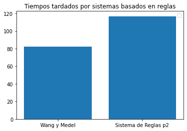

```python
names = [ 'Wang y Mendel','Sistema de Reglas p2']
Y_plt = [(ts1+t1),tiempo_r_2]
#plt.ylim([0.7,0.85])
plt.bar(names,Y_plt)
plt.title('Tiempos tardados por sistemas basados en reglas')
plt.legend()
plt.show()
```

#### Con 3 variables o altura máxima 3

De nuevo, pasamos a estudiar que sucede con tamaños de árboles mayores para el algoritmo de la práctica 2 y mayor cantidad de variables en las reglas para Wang y Mendel.En este caso, a diferencia del caso anterior la precisión del sistema es muy pareja. Los score los podemos comparar con la siguiente gráfica:

```
No artists with labels found to put in legend.  Note that artists whose label start with an underscore are ignored when legend() is called with no argument.
```

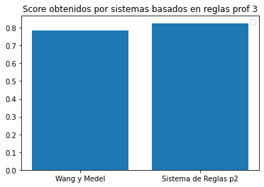

```python
names = [ 'Wang y Mendel','Sistema de Reglas p2']
Y_plt = [score1_2,score_r_3]
#plt.ylim([0.7,0.85])
plt.bar(names,Y_plt)
plt.title('Score obtenidos por sistemas basados en reglas prof 3')
plt.legend()
plt.show()
```

De nuevo, comparamos los tiempos, donde en este caso la mejora de Wang y Mendel es más signiifcativa tal que:

```
No artists with labels found to put in legend.  Note that artists whose label start with an underscore are ignored when legend() is called with no argument.
```

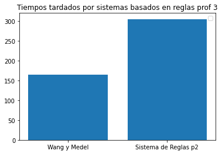

```python
names = [ 'Wang y Mendel','Sistema de Reglas p2']
Y_plt = [(ts1_2+t1_2),tiempo_r_3]
#plt.ylim([0.7,0.85])
plt.bar(names,Y_plt)
plt.title('Tiempos tardados por sistemas basados en reglas prof 3')
plt.legend()
plt.show()
```

#### Profundidad 4 y número de variables 4

La comparativa de scores resulta tal que:

```
No artists with labels found to put in legend.  Note that artists whose label start with an underscore are ignored when legend() is called with no argument.
```

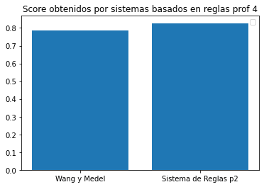

```python
names = [ 'Wang y Mendel','Sistema de Reglas p2']
Y_plt = [score1_3,score_r_4]
#plt.ylim([0.7,0.85])
plt.bar(names,Y_plt)
plt.title('Score obtenidos por sistemas basados en reglas prof 4')
plt.legend()
plt.show()
```

Y de forma respectiva con el tiempo de ejecucuión:

```
No artists with labels found to put in legend.  Note that artists whose label start with an underscore are ignored when legend() is called with no argument.
```

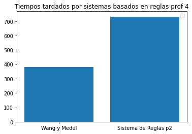

```python
names = [ 'Wang y Mendel','Sistema de Reglas p2']
Y_plt = [(ts1_3+t1_3),tiempo_r_4]
#plt.ylim([0.7,0.85])
plt.bar(names,Y_plt)
plt.title('Tiempos tardados por sistemas basados en reglas prof 4')
plt.legend()
plt.show()
```

Por último, pasamos a comparar la relacion score/tiempo para cada uno de los casos anteriores, para así poder determinar cuál de los dos usaríamos en cada una de estas situaciones. Cabe destacar que para el primero de ellos, si lo que queremos es obtener la mayor precisión posible, habremos de usar el algoritmo de la práctica 2, que proporciona un score significativamente alto frente al de Wang y Mendel. Es por ello que, la relación para el caso de profundidad 2 y número de reglas 2 quedaría tal que:

```
No artists with labels found to put in legend.  Note that artists whose label start with an underscore are ignored when legend() is called with no argument.
```

[figure not shown]

```python
names = [ 'Wang y Mendel','Sistema de Reglas p2']
Y_plt = [score1/(ts1+t1),score_r_2/tiempo_r_2]
#plt.ylim([0.7,0.85])
plt.bar(names,Y_plt)
plt.title('Tiempos tardados por sistemas basados en reglas')
plt.legend()
plt.show()
```

En el caso de usar 3 reglas y una profundidad 3 la relación score/tiempo queda tal que:

```
No artists with labels found to put in legend.  Note that artists whose label start with an underscore are ignored when legend() is called with no argument.
```

[figure not shown]

```python
names = [ 'Wang y Mendel','Sistema de Reglas p2']
Y_plt = [score1_2/(ts1_2+t1_2),score_r_3/tiempo_r_3]
#plt.ylim([0.7,0.85])
plt.bar(names,Y_plt)
plt.title('Score obtenidos por sistemas basados en reglas prof 3')
plt.legend()
plt.show()
```

Por último, para una profundidad máxima de 4 y un número de variables 4, la relación obtenida es:

```
No artists with labels found to put in legend.  Note that artists whose label start with an underscore are ignored when legend() is called with no argument.
```

[figure not shown]

```python
names = [ 'Wang y Mendel','Sistema de Reglas p2']
Y_plt = [score1_3/(ts1_3+t1_3),score_r_4/tiempo_r_4]
#plt.ylim([0.7,0.85])
plt.bar(names,Y_plt)
plt.title('Tiempos tardados por sistemas basados en reglas prof 4')
plt.legend()
plt.show()
```

Con esto podemos concluir que, el de mayor eficiencia a partir de un tamaño 3 es con diferencia Wang y Mendel, donde además cabe destacar que los score obtenidos son similares